# 5-Analyse reproductible

## Intérêt des langages de balisages

- Automatiser la mise en forme du texte
- Séparer le fond de la forme

## Les langages de balisages

- HTML
- LATEX
- Markdown

## HTML

- Structure les contenus
- Très utilisé dans la creation des pages web
- Dans le monde de la data : structuration des rapports, Web Scraping…

## LATEX

- Très utilisé en science, notamment pour les formule
- Produit un Pdf
- Nécessité d’un logiciel pour une sortie en pdf (tinytex, overleaf …)
- Mise en forme agréable
- Compliqué

```latex
\documentclass[french]{article}

\usepackage[
backend=biber,
style=alphabetic,
citestyle=authoryear
]{biblatex}
\addbibresource{These.bib}
\usepackage{amssymb}
\usepackage{hyperref}
\usepackage{url}
\title{CR réunion}
\author{Author}
\date{November 2020}

\begin{document}
\maketitle

\section{21/10/22}
\subsection{fait}
\begin{itemize}
    \item item1
    \item item2
\end{itemize}
\subsection{Discussion}
```

Le latex est très utile pour mettre des formules dans du texte:

- $$\begin{equation}
  x = a_0 + \frac{1}{\displaystyle a_1
  + \frac{1}{\displaystyle a_2
  + \frac{1}{\displaystyle a_3 + a_4}}}
  \end{equation}$$
- $$\begin{equation}
  \bar{x}=\sum_{i=1}^n \frac{x_i}{n}
  \end{equation}$$
- $$\begin{equation}
  I=\int_{a}^bf(x)dx
  \end{equation}$$

## Markdown

- langage de balisage leger
- Syntaxe simple (plus simple que le html)
- Aisé à saisir dans un éditeur de texte
- Lisible sans être formaté
- Intégré dans Rstudio (PDF, word, html)

## Structure d’un Fichier R Markdown

- - En-tête YAML
- - Chunks de code et résultats
- - Texte en Markdown
- https://rstudio.github.io/cheatsheets/rmarkdown.pdf

## R Markdown

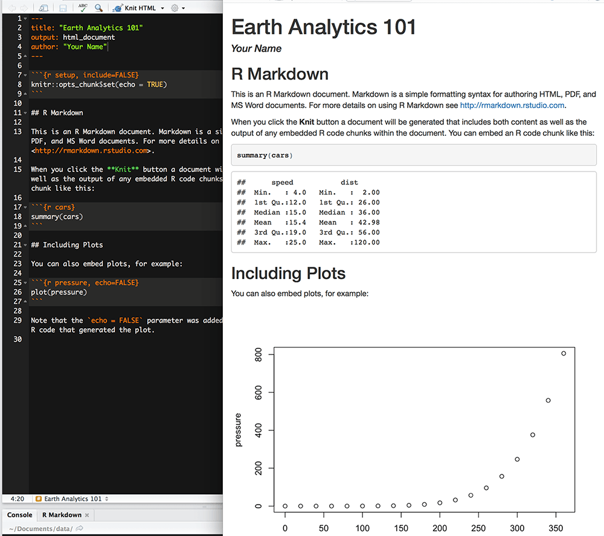

## Exemple en python : Notebook

[figure not shown]

## Gestion de version

## Historique

- SCCS (Source Code Control System) années 80, usage local
- CVS (Concurrent Versions System) années 90 collaboratif mais centralisé
- Subversion (SVN), années 2000 collaboratif mais centralisé
- Git en 2005, chacun a une copie du dépôt, décentralisé

## Gestion de version Git

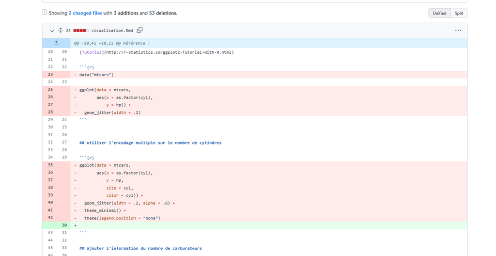

## Git

- Git : systeme de controle de version
- Très pratique pour revenir en arriere , suivre les changement et collaborer
- A fait ses preuves et très utilisé dans le monde du developpement
- Enregistrement des modifications sur plusieurs fichiers
- Installation : https://git-scm.com/downloads
- Documentation : https://git-scm.com/book/fr/v2

## Github

- GitHub qu’est ce que c’est?
- Collaboration avec github
  - Création d’un dépôt GitHub
  - Staging et commit des changements (git add, git commit)
  - Branches et fusion
  - Collaboration et pull request

## Commandes

- Commandes pratiques
  - `cd`
  - `ls`
  - `pwd`

## Commandes git

`git config --global user.name "Votre Nom"`

`git config –-global user.email "vtremail@ex.com"`

- `git init`
- `git clone <url>`
- `git add <fichier> ou git add -A`
- `git commit -m "message"`
- `git push`
- `git pull`
- `git status`

## Packages

- Définition
- Utilité dans le monde de la data
- Packages R et CRAN
- Exemple du package dplyr

## Packages

- Création de package R avec usethis et devtools
  1. Creation du repertoire
  2. Usethis::create_package () ou devtools::create()
  3. Ajouter les foncions dans le dossier R
  4. Mettre l’en-tête requis pour la documentation
  5. devtools::document()
  6. devtools::build()
  7. Et devtools::install :)

## Résumé

- R markdown
- Git
- Packages